# Testing setupsdmdata in modleR

Andrea Sánchez-Tapia & Sara Mortara

2019-07-04

Here we test the function `setup_sdmdata` and its different parametrization options. This function prepares the data to run the models with `do_any` or `do_many` functions. It creates an object in the workspace to be used in `do_any` or `do_many` and writes two csv files with metadata and sdmdata.

Loading required packages.

```r
library(rJava)
library(raster)
library(modleR)
library(maps)
library(maptools)

#eu estou usando uma cópia local para desenvolvimento
#devtools::load_all("../../ModelR")
#mas o pacote pode ser instalado assim:
#devtools::install_github("model-r/modelr_pkg", build_vignettes = TRUE, ref = "petropolis")
```

# Selecting one species as an example

We select only one species from the example data in the package.

```r
# creating a vector with species names
especies <- unique(coordenadas$sp)
# creating a vector with coordinates from species #1
coord1sp <- dplyr::filter(coordenadas, sp == especies[1])
head(coord1sp)
```

```
##                    sp     lon     lat
## 1 Eugenia florida DC. -35.019  -6.379
## 2 Eugenia florida DC. -34.858  -7.775
## 3 Eugenia florida DC. -34.897  -8.102
## 4 Eugenia florida DC. -36.376 -10.421
## 5 Eugenia florida DC. -42.073  -2.722
## 6 Eugenia florida DC. -41.676  -2.920
```

```r
dim(coord1sp) # 341 records
```

```
## [1] 341   3
```

Plotting records of Eugenia florida DC.

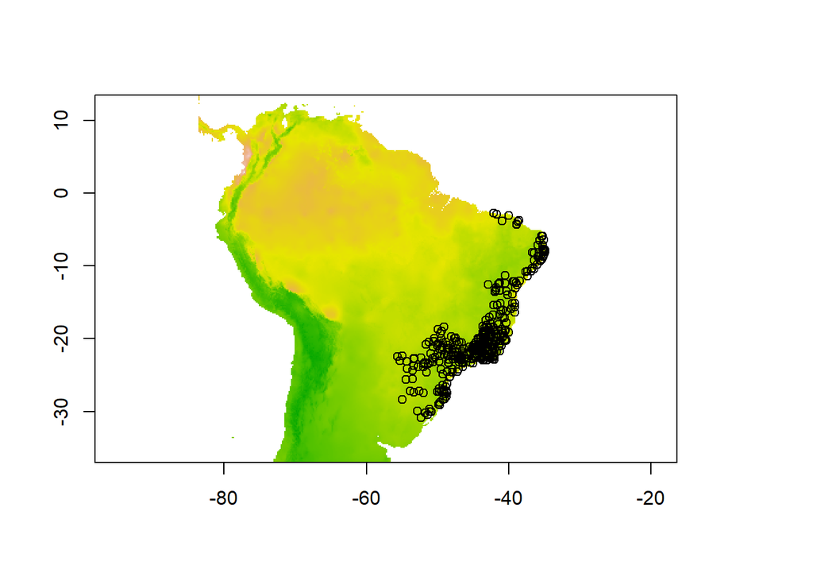

```r
predictor <- example_vars[[1]]
plot(predictor, legend = F)
points(lat ~ lon, data=coord1sp)
```

# Function arguments

Lets explore different arguments in `setup_sdmdata` function.

```
## function (species_name, occurrences, predictors, models_dir = "./models",
##     real_absences = NULL, lon = "lon", lat = "lat", buffer_type = NULL,
##     dist_buf = NULL, dist_min = NULL, buffer_shape = NULL, write_buffer = F,
##     seed = NULL, clean_dupl = FALSE, clean_nas = FALSE, clean_uni = FALSE,
##     geo_filt = FALSE, geo_filt_dist = NULL, select_variables = F,
##     cutoff = 0.8, percent = 0.8, plot_sdmdata = T, n_back = 1000,
##     partition_type = c("bootstrap"), boot_n = 1, boot_proportion = 0.7,
##     cv_n = NULL, cv_partitions = NULL, ...)
## NULL
```

## Default options

First, running with default options. Pseudo-absences are generated in the entire area of the predictor variables and data is partitioned following bootstrap procedures.

```r
a <- setup_sdmdata(species_name = especies[1], # species #01
              occurrences = coord1sp[,-1],
              predictors = example_vars,
              models_dir = "./setupsdmdata/setupsdmdatam",
              real_absences = NULL,
              buffer_type = NULL,
              clean_dupl = T,
              clean_nas = T,
              seed = 512)
```

Exploring the output object from `setup_sdmdata`.

```r
head(a)
```

```
##   boot1 pa     lon     lat   layer.1  layer.2    layer.3   layer.4
## 1     0  1 -35.019  -6.379 -10.80814 7.915253  0.4379055 -6.519020
## 2     0  1 -34.858  -7.775 -11.99225 6.488744  0.6251398 -7.233774
## 3     1  1 -34.897  -8.102 -11.74841 6.457562  0.4323978 -6.026852
## 4     0  1 -36.376 -10.421 -10.58828 7.646321  0.7221881 -6.170407
## 5     1  1 -42.073  -2.722 -11.54698 9.037691 -1.2544334 -6.996859
## 6     1  1 -41.676  -2.920 -11.22910 9.361952 -1.2527254 -7.011737
##      layer.5   layer.6
## 1 -0.7726693 -6.502130
## 2 -0.4791028 -6.157350
## 3 -0.2395393 -5.436216
## 4 -0.7831196 -6.127119
## 5  0.4320937 -7.384173
## 6  0.1556188 -7.586260
```

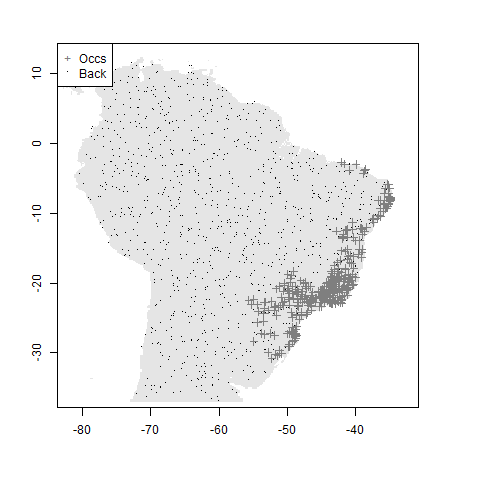

```r
knitr::include_graphics("./setupsdmdata/setupsdmdatam/Eugenia florida DC./present/partitions/sdmdata_Eugenia florida DC..png")
```

### partitioning data with crossvalidation

For crossvalidation we need to specify the number of runs with `cv_n` and partitions with `cv_partitions`.

```r
aa <- setup_sdmdata(species_name = especies[1], # species #01
              occurrences = coord1sp[,-1],
              predictors = example_vars,
              models_dir = "./setupsdmdata/setupsdmdatam_cross",
              partition_type = "crossvalidation",
              cv_n=1,
              cv_partitions=5,
              real_absences = NULL,
              buffer_type = NULL,
              clean_dupl = T,
              clean_nas = T,
              seed = 512)
```

Exploring the new output object.

```r
head(aa)
```

```
##   group.all pa     lon     lat   layer.1  layer.2    layer.3   layer.4
## 1         1  1 -35.019  -6.379 -10.80814 7.915253  0.4379055 -6.519020
## 2         4  1 -34.858  -7.775 -11.99225 6.488744  0.6251398 -7.233774
## 3         1  1 -34.897  -8.102 -11.74841 6.457562  0.4323978 -6.026852
## 4         4  1 -36.376 -10.421 -10.58828 7.646321  0.7221881 -6.170407
## 5         2  1 -42.073  -2.722 -11.54698 9.037691 -1.2544334 -6.996859
## 6         4  1 -41.676  -2.920 -11.22910 9.361952 -1.2527254 -7.011737
##      layer.5   layer.6
## 1 -0.7726693 -6.502130
## 2 -0.4791028 -6.157350
## 3 -0.2395393 -5.436216
## 4 -0.7831196 -6.127119
## 5  0.4320937 -7.384173
## 6  0.1556188 -7.586260
```

## Exploring different generations of pseudo-absences with `buffer_type`

### mean buffer

Buffer for pseudo-absence generation based on mean distance between occurrence points.

```r
b <- setup_sdmdata(species_name = especies[1],
              occurrences = coord1sp[,-1],
              predictors = example_vars,
              models_dir = "./setupsdmdata/setupsdmdatan",
              real_absences = NULL,
              buffer_type = "mean",
              clean_dupl = T,
              clean_nas = T,
              seed = 512)
```

```r
head(b)
```

```
##   boot1 pa     lon     lat   layer.1  layer.2    layer.3   layer.4
## 1     1  1 -35.019  -6.379 -10.80814 7.915253  0.4379055 -6.519020
## 2     0  1 -34.858  -7.775 -11.99225 6.488744  0.6251398 -7.233774
## 3     1  1 -34.897  -8.102 -11.74841 6.457562  0.4323978 -6.026852
## 4     0  1 -36.376 -10.421 -10.58828 7.646321  0.7221881 -6.170407
## 5     1  1 -42.073  -2.722 -11.54698 9.037691 -1.2544334 -6.996859
## 6     1  1 -41.676  -2.920 -11.22910 9.361952 -1.2527254 -7.011737
##      layer.5   layer.6
## 1 -0.7726693 -6.502130
## 2 -0.4791028 -6.157350
## 3 -0.2395393 -5.436216
## 4 -0.7831196 -6.127119
## 5  0.4320937 -7.384173
## 6  0.1556188 -7.586260
```

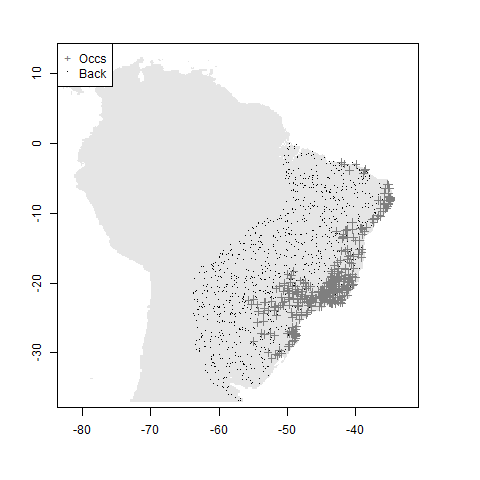

```r
knitr::include_graphics("./setupsdmdata/setupsdmdatan/Eugenia florida DC./present/partitions/sdmdata_Eugenia florida DC..png")
```

### buffer median

Buffer for pseudo-absence generation based on median of distance between occurrence points.

```r
c <- setup_sdmdata(species_name = especies[1],
              occurrences = coord1sp[,-1],
              predictors = example_vars,
              models_dir = "./setupsdmdata/setupsdmdatap",
              real_absences = NULL,
              buffer_type = "median",
              clean_dupl = T,
              clean_nas = T,
              seed = 512)
```

```r
head(c)
```

```
##   boot1 pa     lon     lat   layer.1  layer.2    layer.3   layer.4
## 1     1  1 -35.019  -6.379 -10.80814 7.915253  0.4379055 -6.519020
## 2     0  1 -34.858  -7.775 -11.99225 6.488744  0.6251398 -7.233774
## 3     1  1 -34.897  -8.102 -11.74841 6.457562  0.4323978 -6.026852
## 4     0  1 -36.376 -10.421 -10.58828 7.646321  0.7221881 -6.170407
## 5     1  1 -42.073  -2.722 -11.54698 9.037691 -1.2544334 -6.996859
## 6     1  1 -41.676  -2.920 -11.22910 9.361952 -1.2527254 -7.011737
##      layer.5   layer.6
## 1 -0.7726693 -6.502130
## 2 -0.4791028 -6.157350
## 3 -0.2395393 -5.436216
## 4 -0.7831196 -6.127119
## 5  0.4320937 -7.384173
## 6  0.1556188 -7.586260
```

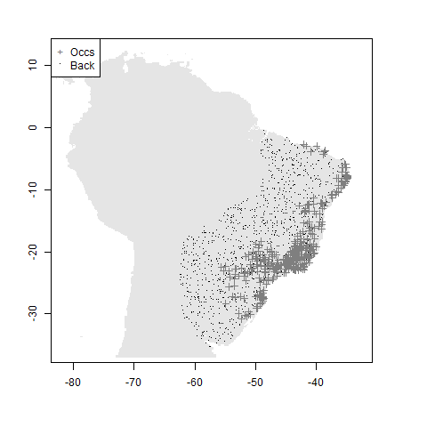

```r
knitr::include_graphics("./setupsdmdata/setupsdmdatap/Eugenia florida DC./present/partitions/sdmdata_Eugenia florida DC..png")
```

### buffer max

Buffer for pseudo-absence generation based on maximum distance between occurrence points.

```r
d <- setup_sdmdata(species_name = especies[1],
              occurrences = coord1sp[,-1],
              predictors = example_vars,
              models_dir = "./setupsdmdata/setupsdmdatax",
              real_absences = NULL,
              buffer_type = "max",
              clean_dupl = T,
              clean_nas = T,
              seed = 512)
```

```r
head(d)
```

```
##   boot1 pa     lon     lat   layer.1  layer.2    layer.3   layer.4
## 1     0  1 -35.019  -6.379 -10.80814 7.915253  0.4379055 -6.519020
## 2     0  1 -34.858  -7.775 -11.99225 6.488744  0.6251398 -7.233774
## 3     1  1 -34.897  -8.102 -11.74841 6.457562  0.4323978 -6.026852
## 4     0  1 -36.376 -10.421 -10.58828 7.646321  0.7221881 -6.170407
## 5     0  1 -42.073  -2.722 -11.54698 9.037691 -1.2544334 -6.996859
## 6     1  1 -41.676  -2.920 -11.22910 9.361952 -1.2527254 -7.011737
##      layer.5   layer.6
## 1 -0.7726693 -6.502130
## 2 -0.4791028 -6.157350
## 3 -0.2395393 -5.436216
## 4 -0.7831196 -6.127119
## 5  0.4320937 -7.384173
## 6  0.1556188 -7.586260
```

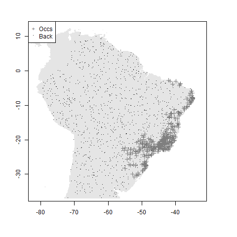

```r
knitr::include_graphics("./setupsdmdata/setupsdmdatax/Eugenia florida DC./present/partitions/sdmdata_Eugenia florida DC..png")
```

### buffer dist

Buffer for pseudo-absence generation based on specific distance between occurrence points. In this case `dist_buf` argument must be specified.

```r
e <- setup_sdmdata(species_name = especies[1],
              occurrences = coord1sp[,-1],
              predictors = example_vars,
              models_dir = "./setupsdmdata/setupsdmdataxd",
              real_absences = NULL,
              buffer_type = "distance",
              dist_buf = 4,
              clean_dupl = T,
              clean_nas = T,
              seed = 512)
```

```r
head(e)
```

```
##   boot1 pa     lon     lat   layer.1  layer.2    layer.3   layer.4
## 1     0  1 -35.019  -6.379 -10.80814 7.915253  0.4379055 -6.519020
## 2     0  1 -34.858  -7.775 -11.99225 6.488744  0.6251398 -7.233774
## 3     1  1 -34.897  -8.102 -11.74841 6.457562  0.4323978 -6.026852
## 4     0  1 -36.376 -10.421 -10.58828 7.646321  0.7221881 -6.170407
## 5     1  1 -42.073  -2.722 -11.54698 9.037691 -1.2544334 -6.996859
## 6     1  1 -41.676  -2.920 -11.22910 9.361952 -1.2527254 -7.011737
##      layer.5   layer.6
## 1 -0.7726693 -6.502130
## 2 -0.4791028 -6.157350
## 3 -0.2395393 -5.436216
## 4 -0.7831196 -6.127119
## 5  0.4320937 -7.384173
## 6  0.1556188 -7.586260
```

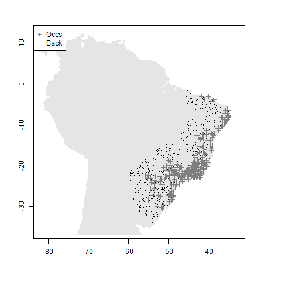

```r
knitr::include_graphics("./setupsdmdata/setupsdmdataxd/Eugenia florida DC./present/partitions/sdmdata_Eugenia florida DC..png")
```

### user defined buffer: the user provide a shapefile. Maptools package to read the “.shp” file

myshapefile <- readShapePoly(“data/myshapefile.shp”)

```r
f <- setup_sdmdata(species_name = especies[1],
              occurrences = coord1sp[,-1],
              predictors = example_vars,
              models_dir = "./setupsdmdata/setupsdmdataub",
              real_absences = NULL,
              buffer_type = "user",
              buffer_shape = myshapefile,
              clean_dupl = T,
              clean_nas = T,
              seed = 512)
```

```r
head(f)
```

```
##   boot1 pa     lon     lat   layer.1  layer.2    layer.3   layer.4
## 1     1  1 -35.019  -6.379 -10.80814 7.915253  0.4379055 -6.519020
## 2     0  1 -34.858  -7.775 -11.99225 6.488744  0.6251398 -7.233774
## 3     1  1 -34.897  -8.102 -11.74841 6.457562  0.4323978 -6.026852
## 4     0  1 -36.376 -10.421 -10.58828 7.646321  0.7221881 -6.170407
## 5     1  1 -42.073  -2.722 -11.54698 9.037691 -1.2544334 -6.996859
## 6     1  1 -41.676  -2.920 -11.22910 9.361952 -1.2527254 -7.011737
##      layer.5   layer.6
## 1 -0.7726693 -6.502130
## 2 -0.4791028 -6.157350
## 3 -0.2395393 -5.436216
## 4 -0.7831196 -6.127119
## 5  0.4320937 -7.384173
## 6  0.1556188 -7.586260
```

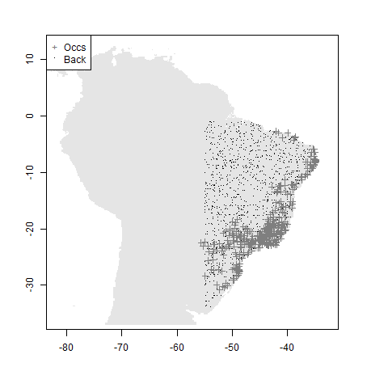

```r
knitr::include_graphics("./setupsdmdata/setupsdmdataub/Eugenia florida DC./present/partitions/sdmdata_Eugenia florida DC..png")
```